# Game of Thrones Bipartite Network

This notebook explores battles from the *Game of Thrones* universe using a bipartite network approach.

We connect **characters** (kings, houses) to the **battles** they participated in.

By projecting the bipartite graph, we can uncover:

- Which Kings House were central across multiple conflicts.
- How alliances and rivalries shaped the war network.

**Dataset:** [Game of Thrones Battles and Deaths (Kaggle)](https://www.kaggle.com/datasets/thedevastator/game-of-thrones-battles-and-deaths?resource=download)

```
✅ Libraries loaded successfully!
```

Loading the csv into a pandas DataFrame:

```
Dataset shape: (38, 26)
```

|  | index | name | year | battle_number | attacker_king | defender_king | attacker_1 | attacker_2 | attacker_3 | attacker_4 | defender_1 | defender_2 | defender_3 | defender_4 | attacker_outcome | battle_type | major_death | major_capture | attacker_size | defender_size | attacker_commander | defender_commander | summer | location | region | note |
| --- | --- | --- | --- | --- | --- | --- | --- | --- | --- | --- | --- | --- | --- | --- | --- | --- | --- | --- | --- | --- | --- | --- | --- | --- | --- | --- |
| 0 | 0 | Battle of the Golden Tooth | 298 | 1 | Joffrey/Tommen Baratheon | Robb Stark | Lannister | NaN | NaN | NaN | Tully | NaN | NaN | NaN | win | pitched battle | 1.0 | 0.0 | 15000.0 | 4000.0 | Jaime Lannister | Clement Piper, Vance | 1.0 | Golden Tooth | The Westerlands | NaN |
| 1 | 1 | Battle at the Mummer's Ford | 298 | 2 | Joffrey/Tommen Baratheon | Robb Stark | Lannister | NaN | NaN | NaN | Baratheon | NaN | NaN | NaN | win | ambush | 1.0 | 0.0 | NaN | 120.0 | Gregor Clegane | Beric Dondarrion | 1.0 | Mummer's Ford | The Riverlands | NaN |
| 2 | 2 | Battle of Riverrun | 298 | 3 | Joffrey/Tommen Baratheon | Robb Stark | Lannister | NaN | NaN | NaN | Tully | NaN | NaN | NaN | win | pitched battle | 0.0 | 1.0 | 15000.0 | 10000.0 | Jaime Lannister, Andros Brax | Edmure Tully, Tytos Blackwood | 1.0 | Riverrun | The Riverlands | NaN |
| 3 | 3 | Battle of the Green Fork | 298 | 4 | Robb Stark | Joffrey/Tommen Baratheon | Stark | NaN | NaN | NaN | Lannister | NaN | NaN | NaN | loss | pitched battle | 1.0 | 1.0 | 18000.0 | 20000.0 | Roose Bolton, Wylis Manderly, Medger Cerwyn, H... | Tywin Lannister, Gregor Clegane, Kevan Lannist... | 1.0 | Green Fork | The Riverlands | NaN |
| 4 | 4 | Battle of the Whispering Wood | 298 | 5 | Robb Stark | Joffrey/Tommen Baratheon | Stark | Tully | NaN | NaN | Lannister | NaN | NaN | NaN | win | ambush | 1.0 | 1.0 | 1875.0 | 6000.0 | Robb Stark, Brynden Tully | Jaime Lannister | 1.0 | Whispering Wood | The Riverlands | NaN |

Building our graph from the DataFrame

```
✅ Typed bipartite graph built with 65 nodes and 159 edges.
```

```
[('Joffrey/Tommen Baratheon',
  'Battle of the Golden Tooth',
  {'role': 'attacker'}),
 ('Joffrey/Tommen Baratheon',
  "Battle at the Mummer's Ford",
  {'role': 'attacker'}),
 ('Joffrey/Tommen Baratheon', 'Battle of Riverrun', {'role': 'attacker'}),
 ('Joffrey/Tommen Baratheon',
  'Battle of the Green Fork',
  {'role': 'defender'}),
 ('Joffrey/Tommen Baratheon',
  'Battle of the Whispering Wood',
  {'role': 'defender'}),
 ('Joffrey/Tommen Baratheon', 'Battle of the Camps', {'role': 'defender'}),
 ('Joffrey/Tommen Baratheon', 'Sack of Darry', {'role': 'attacker'}),
 ('Joffrey/Tommen Baratheon', 'Sack of Winterfell', {'role': 'attacker'}),
 ('Joffrey/Tommen Baratheon', 'Battle of Oxcross', {'role': 'defender'}),
 ('Joffrey/Tommen Baratheon', 'Battle of the Fords', {'role': 'attacker'})]
```

[output not shown]

After loading the bipartite graph, we can project it to analyze relationships among characters based on shared battles.

```
✅ Battle projection built with 38 battles and 520 connections.
```

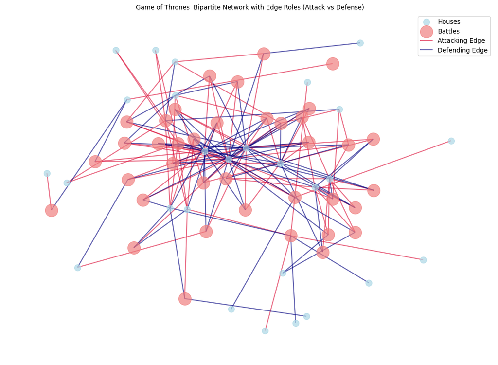

```
✅ Island base network built with 37 nodes and 37 weighted connections.
```

We now implement a weighted island method to identify key battles within allegiance networks. We start with the battle network with edges to other battles with atleast one shared house in each and progress to 6. We see Island emeergings for key battles campaing in the series that shaped the story.

[figure not shown]

[figure not shown]

[figure not shown]

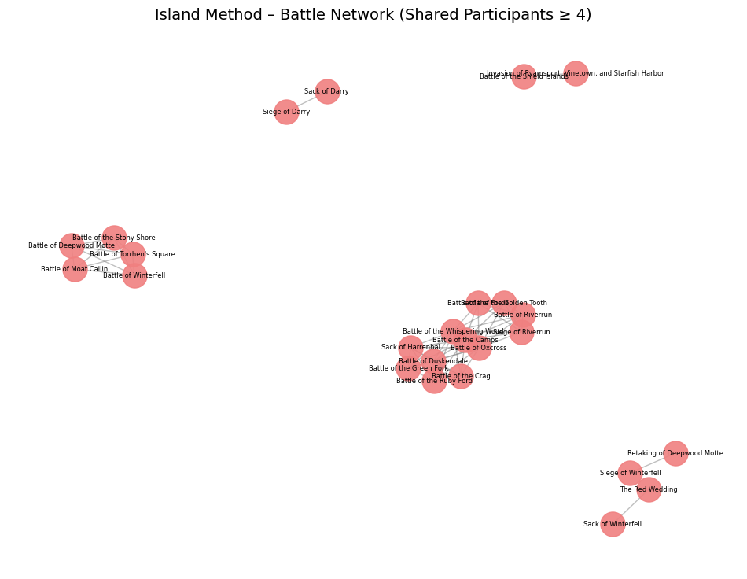

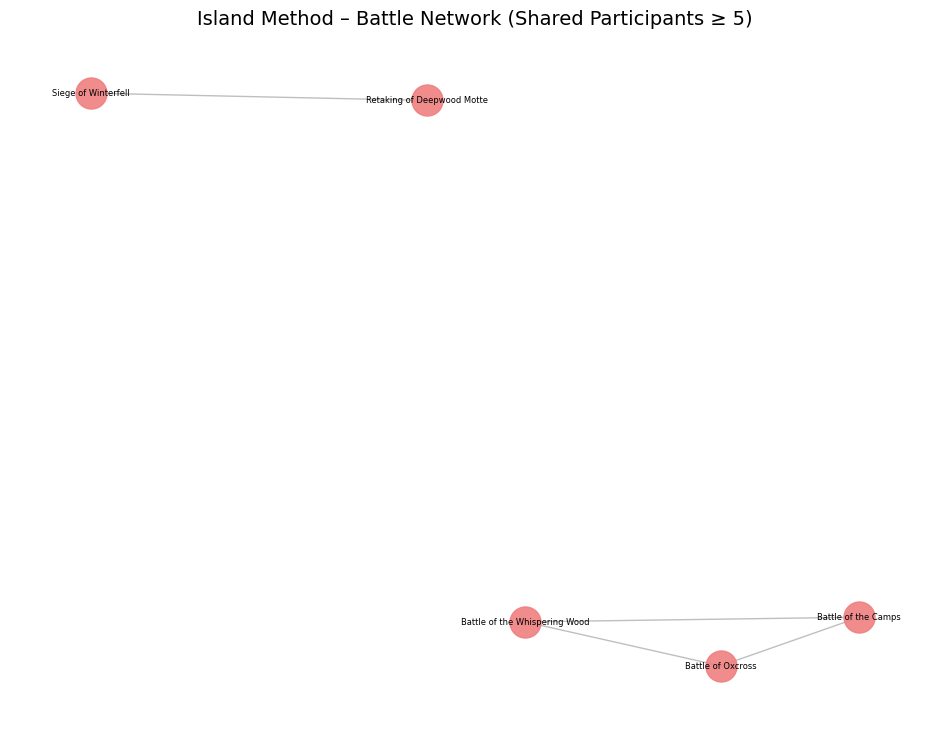

[figure not shown]

Our interesting level for shared houses is 4, as it highlights significant battles with the same belliegerents and pointing to strageic events that shape the story for instance the battles along the the northern shore then Theon betrays the Starks and captures Winterfell. The battles around the Riverlands signifying the turmiol during Robb's Starks uprising and the instability after the Red Wedding. We also see the isolated networks with the battles on the shield islands an Euron makes his bid for a bigger part of the 7 kigndoms.

We now take a look at unitpate graph amoun houdes to understand the alliances and rivalries that shaped the war network.

```
✅ Projected character graph created with 27 nodes and 107 edges.
```

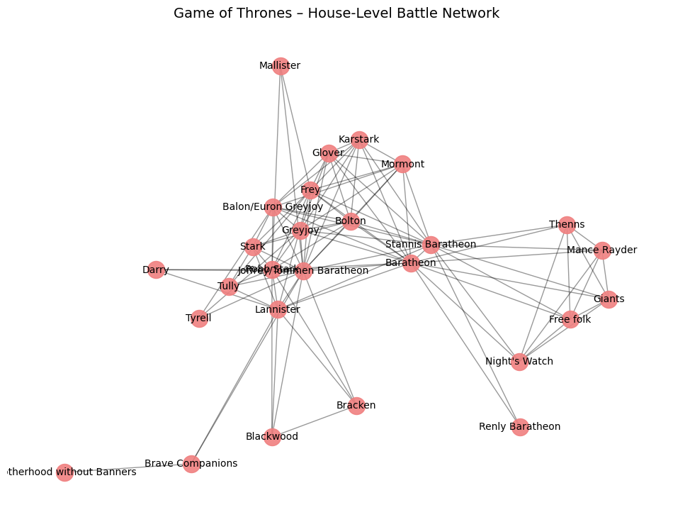

```
✅ Attack projection: 27 nodes, 31 edges
✅ Defense projection: 27 nodes, 18 edges
```

For the Follwing analysis I further filtered the data to only include battles with known attackers and defenders, ensuring a more accurate representation of the conflict dynamics. And then I take a look at the the top 20 Attacker and Defenders through their connections in shared battles to understand any alligiences that developed.

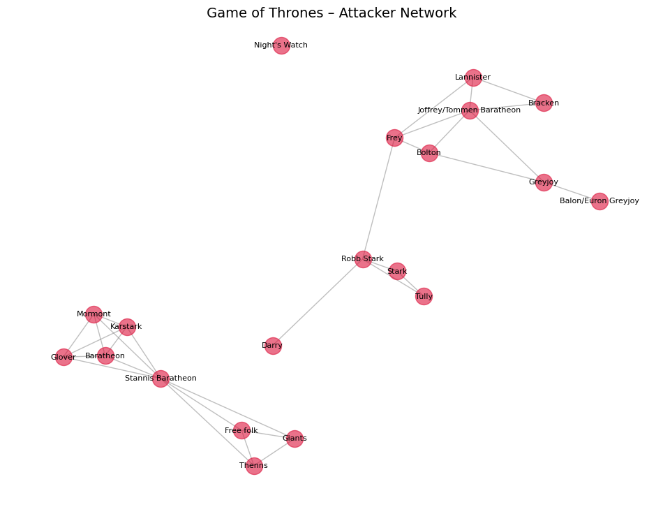

So as we SubA attackers that were on the same side in battles with atleast 20 shared connections we see the following: Stark-Tully, Stannis-Free Folk, Lannister-Bolton-Frey, and as expected we see Frey inbtween the starks and lannisters as they were involved in the red wedding.

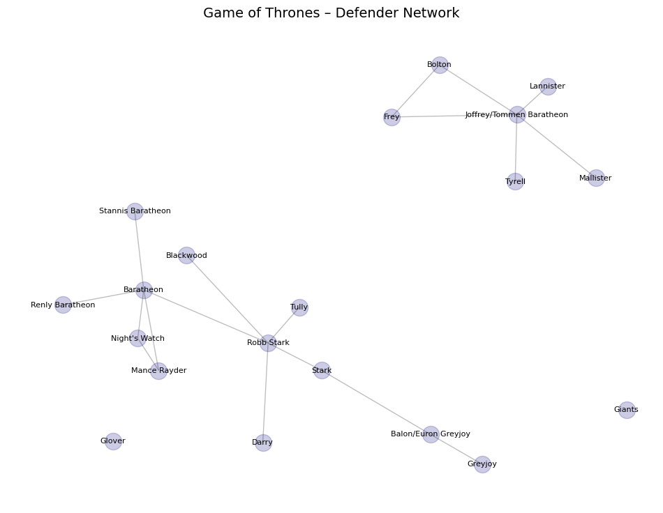

In the Defender network we see some diffrences notably the Strak Island now is linked to the Greyjoy line as they were involved in battles before Theon betrays Robb. We also see a clear alliance formed between the Lannisters -Tyrells-Boltons-Freys having cemented their power through the red wedding and the battle of the blackwater. Stannis and and the peoples north of the war have also a clear formed alliance as we know from their battles against the dead and the boltons.

```
 Top Central Characters/Houses by Degree:
                          Degree  Betweenness
Joffrey/Tommen Baratheon      27     0.429280
Robb Stark                    24     0.154100
Lannister                     18     0.100946
Stark                         16     0.051868
Greyjoy                       11     0.049841
Balon/Euron Greyjoy           10     0.043018
Baratheon                      8     0.144160
Tully                          7     0.003118
Stannis Baratheon              7     0.100698
Frey                           4     0.009350
```

We measured the degree and betweenness centrality of all characters and houses within the bipartite battle network. As expected, House Lannister and House Stark emerge as the most central actors, reflecting their dominance across multiple fronts of the war.

Smaller houses such as Greyjoy, Tully, and Frey appear with moderate to low centrality, indicating regional participation or alliance-based involvement rather than sustained warfare across multiple theaters. Overall, the centrality measures reinforce the narrative hierarchy of power: the Lannister–Baratheon bloc dominates the conflict structure, while the Stark coalition represents the main opposition force.

```
 Top Central Battles by Degree:
                               Degree  Betweenness
Siege of Winterfell                 8     0.115158
Retaking of Deepwood Motte          7     0.073851
Battle of Castle Black              7     0.151406
Battle of the Whispering Wood       5     0.009531
Battle of the Camps                 5     0.009531
Siege of Riverrun                   5     0.013250
Siege of Raventree                  5     0.063690
Sack of Winterfell                  5     0.016451
The Red Wedding                     5     0.017337
Battle of Oxcross                   5     0.009531
```

```
 Top Central Attackers by Degree and Betweenness:
                          Degree  Betweenness
Frey                           5     0.154971
Robb Stark                    13     0.134503
Stannis Baratheon             12     0.070175
Bolton                         5     0.064327
Greyjoy                        8     0.061404
Tully                          6     0.052632
Lannister                     11     0.032164
Joffrey/Tommen Baratheon      16     0.020468
Bracken                        2     0.011696
Baratheon                      9     0.000000
```

```
 Top Central Attackers by Degree and Betweenness:
                          Degree  Betweenness
Robb Stark                    14     0.245614
Baratheon                      6     0.192982
Stark                          8     0.105263
Balon/Euron Greyjoy            4     0.058480
Joffrey/Tommen Baratheon      14     0.052632
Bolton                         2     0.000000
Greyjoy                        3     0.000000
Lannister                      9     0.000000
Stannis Baratheon              2     0.000000
Mance Rayder                   2     0.000000
```

For the defense subgraph, we see that Robb Stark is the central figure in terms of betweenness, highlighting his critical role in connecting various battles and factions. This is consistent with his leadership during the Northern rebellion and his efforts to unite different houses against common enemies. The high betweenness centrality of Robb Stark shows that he was a key intermediary in the network of battles, helping to form alliances and coordinate defensive movements across the North.